# Population size structure, not species turnover, tracks environmental gradients across a diverse Indo-Pacific *Pocillopora* assembledge

Statistical analysis and visualization pipeline

Published

June 21, 2026

# Setup

## Load packages

```r
library(tidyverse)
library(vegan)
library(ordinal)
library(mvabund)

library(scales)
library(ggrepel)
library(corrplot)
library(patchwork)
library(knitr)
library(kableExtra)
library(viridis)
library(ggmap)
library(ggsn)
library(ggh4x)
```

```r
## Load Site Map
register_google(
  key = Sys.getenv("GOOGLE_MAPS_API_KEY")
)
# location
Moorea<-data.frame(lon = -149.83246425684064, lat = -17.531092816791094)

#Map base
M1<-get_map(Moorea,zoom = 12, maptype = 'satellite')

bbx <- c(left=-149.802,bottom= -17.480,right=-149.805,top=-17.475)
x <- c(bbx["left"], bbx["left"], bbx["right"], bbx["right"])
y <- c(bbx["bottom"], bbx["top"], bbx["top"], bbx["bottom"])
df <- data.frame(x, y)

sitedata <- read.csv("../Data/site.coords.csv")
str(sitedata)
```

```
'data.frame':   11 obs. of  4 variables:
 $ long : num  -150 -150 -150 -150 -150 ...
 $ lat  : num  -17.5 -17.5 -17.5 -17.5 -17.5 ...
 $ Site : chr  "S2" "S3" "S4" "S5" ...
 $ shore: chr  "North" "North" "North" "North" ...
```

[figure not shown]

```r
labels <- sitedata$Site


map_plot <- ggmap(M1) +
  geom_point(
    data = sitedata,
    aes(x = long, y = lat, fill = shore),
    shape = 21,
    size = 3,
    color = "white",
    stroke = 0.5
  ) +
  scale_fill_manual(
    values = c(
      "North" = "turquoise2",
      "East"  = "palegreen1",
      "West"  = "plum2"
    )
  ) +
  geom_text(
    data = sitedata,
    aes(x = long, y = lat, label = Site),
    vjust = -1,
    size = 3,
    color = "white"
  ) +
  scalebar(
    data = sitedata,
    dist = 2,
    dist_unit = "km",
    transform = TRUE,
    model = "WGS84",
    st.size = 2,
    st.color = "white",
    box.color = "white",
    height = 0.001,
    location = "bottomleft"
  ) +
  xlab("") +
  ylab("")

map_plot
```

## Load data

```r
size_data <- read_csv("../Data/pocillopora_site_species_size_density.csv")
env_data  <- read_csv("../Data/sites_env_hyp.csv")
```

## Data preparation

Missing species × size class × site combinations are filled with zero density, reflecting true absences rather than missing observations.

#### Factor levels defined

Ordered factors for 4 size classes, 6 *Pocillopora* species, and **5 environmental predictors**: `max_temp_br`, `daily_range_br`, `Hard_Coral`, `CTB_algae` (CTB + Macroalgae combined), and `wave_P_max`. CTB and macroalgae are pre-combined into a single composite (`CTB_algae`) at the data preparation stage so that the same variable definition is used consistently across NMDS, PERMANOVA, and OLR. CTB provides hard substrate that facilitates larval settlement and recruitment; macroalgae can compete with, damage, or smother established colonies and block larval settlement. A further reduced **3-predictor set** (`daily_range_br`, `wave_P_max`, `CTB_algae`) is used for OLR only, where sample size (n = 11) limits the number of estimable parameters; `max_temp_br` is dropped due to collinearity with wave power (ρ = 0.78) and `Hard_Coral` is dropped due to low explanatory priority given its moderate collinearity with both wave power (ρ = 0.71) and daily temperature range (ρ = 0.66).

#### Zero-filling

All site × species × size class combinations are completed via `expand_grid()` + `left_join()`, with missing densities replaced by 0 (true absences, not missing data).

#### Joined long-format dataset (`data_full`)

The zero-filled size data is joined to the cleaned environmental data. `site.name` is set as an ordered factor matching geographic sequence (S2–S18).

#### Multivariate matrices

- `comm_wide` / `comm_mat`: a sites × (species × size class) community matrix for multivariate analyses (e.g., PERMANOVA), with special characters replaced by underscores in column names.
- `env_mat`: a matching sites × 5-predictor environmental matrix, same site order as `comm_mat`.
- `env_perm`: a version of the environmental data with `shore` as a plain character vector, suitable for `adonis2()`.

#### Standardization

All 5 environmental predictors are z-scored (appended as `*_z` columns) for use in regression models. Because `CTB_algae` is in `env_vars`, `CTB_algae_z` is created automatically by the `across()` call.

```r
# Ordered factor levels
size_levels    <- c("0-2cm", ">2cm-5cm", ">5cm-14cm", ">14cm")
species_levels <- c("P. acuta", "P. effusa", "P. grandis",
                    "P. meandrina", "P. tuahiniensis", "P. verrucosa")
env_vars <- c("max_temp_br", "daily_range_br", "Hard_Coral", "CTB_algae", "wave_P_max")
env_labels <- c("Max temp (°C)", "Daily temp range (°C)", "Hard coral",
                "CTB + Macro", "Max wave power")
env_label_map <- setNames(env_labels, env_vars)

shore_cols      <- c(North = "#4BACC6", East = "#70AD47", West = "#C55A94")

# Reduced 3-predictor set for OLR (5 → 3 for sample-size constraints at n = 11)
# max temp dropped — collinear with wave power (ρ = 0.78); Hard Coral dropped — low explanatory priority
# CTB_algae retained: captures both recruitment substrate availability (CTB) and macroalgal competition/smothering pressure
olr_vars   <- c("daily_range_br", "wave_P_max",      "CTB_algae")
olr_vars_z <- c("daily_range_br_z", "wave_P_max_z",  "CTB_algae_z")
olr_labels <- c("Daily temp range (°C)", "Max wave power", "CTB + Macro")

# Complete all species × size class × site combinations with zeros
size_complete <- expand_grid(
  site.name = unique(size_data$site.name),
  Species   = species_levels,
  SizeClass = size_levels
) |>
  left_join(
    size_data |> select(site.name, Species, SizeClass, Density_m2),
    by = c("site.name", "Species", "SizeClass")
  ) |>
  mutate(
    Density_m2 = replace_na(Density_m2, 0),
    SizeClass  = factor(SizeClass, levels = size_levels),
    Species    = factor(Species,   levels = species_levels)
  )

# Environmental data with ordered shore factor; CTB_algae composite computed here
# so it is available for env_mat and all downstream analyses
env_clean <- env_data |>
  mutate(
    shore     = factor(shore, levels = c("North", "East", "West")),
    CTB_algae = CTB + Macroalgae
  )

# Full joined dataset (long format)
data_full <- size_complete |>
  left_join(env_clean, by = "site.name")

data_full <- data_full |>
  mutate(
    site.name = factor(site.name, levels = c("S18", "S15", "S14", "S12", "S11", "S9",
                                             "S6", "S5","S4", "S3", "S2"))
)

# Wide-format community matrix for multivariate analyses
# Special characters in species/size names replaced with underscores
comm_wide <- size_complete |>
  mutate(sp_size = gsub("[^A-Za-z0-9]", "_",
                        paste(as.character(Species),
                              as.character(SizeClass), sep = "_"))) |>
  select(site.name, sp_size, Density_m2) |>
  pivot_wider(names_from  = sp_size,
              values_from = Density_m2,
              values_fill = 0) |>
  arrange(site.name)

# Community matrix (rows = sites, cols = species × size class)
comm_mat <- comm_wide |>
  column_to_rownames("site.name") |>
  as.matrix()

# Environmental predictor matrix (same site order as comm_mat)
env_mat <- env_clean |>
  arrange(site.name) |>
  column_to_rownames("site.name") |>
  select(all_of(env_vars)) |>
  as.data.frame()

# env data frame for permutation tests (shore as character for adonis2)
env_perm <- env_clean |>
  arrange(site.name) |>
  mutate(shore = as.character(shore)) |>
  column_to_rownames("site.name")

# Standardized (z-scored) env predictors — used by regression models
# CTB_algae is in env_vars so CTB_algae_z is created automatically by across()
env_vars_z <- paste0(env_vars, "_z")
env_clean <- env_clean |>
  mutate(across(all_of(env_vars), ~scale(.)[, 1], .names = "{.col}_z"))
```

#### Chunk 1 summary

The dataset includes 11 sites, 6 *Pocillopora* species, and 4 size classes, yielding 264 site × species × size-class observations after zero-filling.

# Data overview of Environmental variables by site

Before modeling, examine data as a pre-modeling sanity check for a site-by-site view of temperature, benthic cover, and wave conditions before any analysis.

```r
env_clean |>
  arrange(site.name) |>
  select(site.name, shore, all_of(env_vars)) |>
  rename(Site = site.name, Shore = shore) |>
  rename_with(~env_labels, all_of(env_vars)) |>
  kable(
    digits  = 3,
    caption = "Environmental variables measured at each study site."
  ) |>
  kable_styling(
    bootstrap_options = c("striped", "hover", "condensed"),
    full_width = FALSE
  )
```

Environmental variables measured at each study site.

| Site | Shore | Max temp (°C) | Daily temp range (°C) | Hard coral | CTB + Macro | Max wave power |
| --- | --- | --- | --- | --- | --- | --- |
| S11 | East | 31.585 | 0.918 | 0.151 | 0.619 | 107.577 |
| S12 | West | 31.444 | 0.815 | 0.186 | 0.532 | 188.769 |
| S14 | West | 31.660 | 0.988 | 0.228 | 0.585 | 188.769 |
| S15 | West | 31.728 | 0.956 | 0.255 | 0.494 | 188.769 |
| S18 | West | 31.278 | 1.382 | 0.199 | 0.602 | 188.769 |
| S2 | North | 30.956 | 0.731 | 0.030 | 0.931 | 57.400 |
| S3 | North | 31.128 | 0.673 | 0.039 | 0.761 | 57.400 |
| S4 | North | 30.824 | 0.792 | 0.076 | 0.244 | 57.400 |
| S5 | North | 30.552 | 0.805 | 0.136 | 0.535 | 57.400 |
| S6 | East | 31.048 | 0.726 | 0.228 | 0.525 | 107.577 |
| S9 | East | 30.934 | 0.573 | 0.018 | 0.906 | 107.577 |

## Correlations among environmental predictors

Before modeling, inspect collinearity among the five predictors. CTB and macroalgae are pre-combined into `CTB_algae`, a composite capturing both CTB as recruitment substrate and macroalgae as a source of competition and smothering pressure on established colonies. Highly correlated predictors (|ρ| > 0.7) should not be included in the same model.

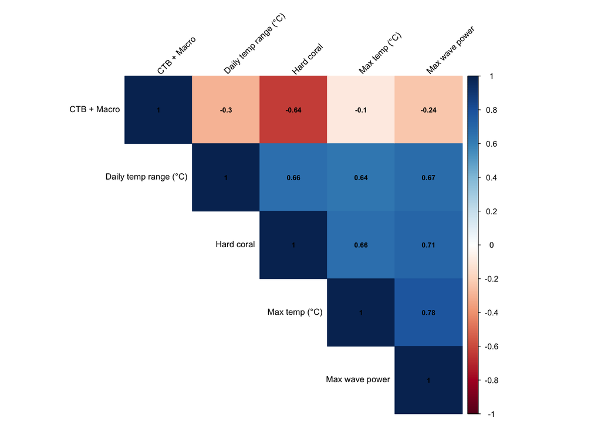

**Supplemental Figure 1a.** Spearman rank correlations among the five environmental predictors. CTB and macroalgae are pre-combined into a single composite (CTB + Macro) capturing both recruitment substrate availability (CTB) and macroalgal competition and smothering pressure. Variables are clustered by hierarchical clustering. Number in each cell = ρ. Collinear predictors (|ρ| > 0.7) should not be included simultaneously in multivariate models.

```r
cor_env <- cor(env_mat, method = "spearman")
colnames(cor_env) <- rownames(cor_env) <- env_labels

corrplot(
  cor_env,
  method      = "color",
  type        = "upper",
  order       = "hclust",
  tl.col      = "black",
  tl.srt      = 45,
  tl.cex      = 0.85,
  addCoef.col = "black",
  number.cex  = 0.70,
  mar         = c(0, 0, 1, 0)
)
```

#### Summary

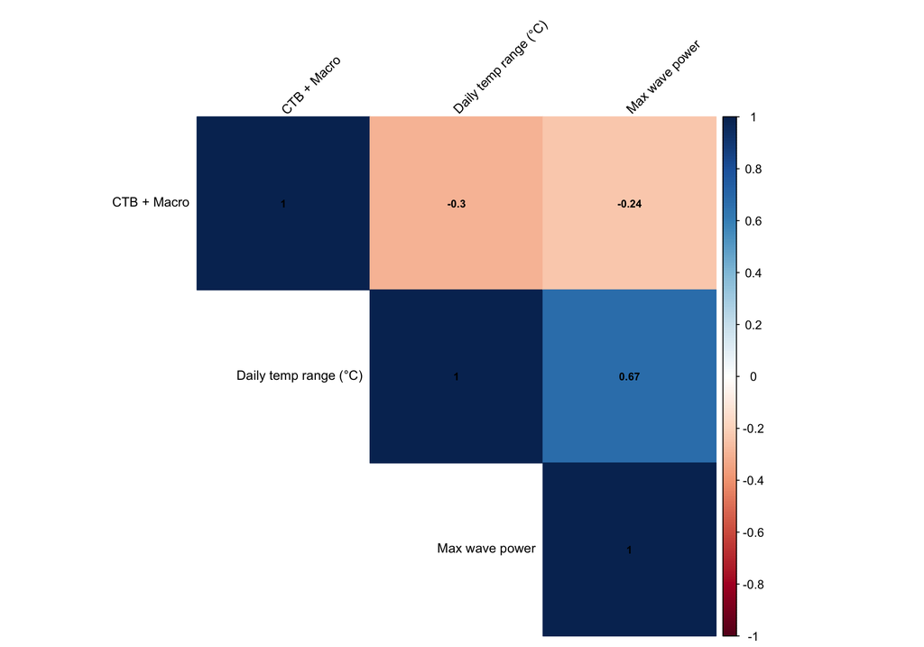

**Supplemental Figure 1b.** Spearman rank correlations among the reduced 3-predictor set used in OLR models: daily temperature range, maximum wave power, and CTB + Macro (a composite of CTB as recruitment substrate and macroalgae as a source of competition and smothering pressure). Number in each cell = ρ.

```r
cor_olr <- env_clean |>
  select(all_of(olr_vars)) |>
  cor(method = "spearman")
colnames(cor_olr) <- rownames(cor_olr) <- olr_labels

corrplot(
  cor_olr,
  method      = "color",
  type        = "upper",
  order       = "hclust",
  tl.col      = "black",
  tl.srt      = 45,
  tl.cex      = 0.85,
  addCoef.col = "black",
  number.cex  = 0.70,
  mar         = c(0, 0, 1, 0)
)
```

#### Summary

env-correlation-olr (Supplemental Figure 1b) — Reduced OLR set Computes the same Spearman correlation for the 3-predictor OLR subset (daily_range_br, wave_P_max, CTB_algae) drawn from env_clean. Uses identical plot styling for direct comparison. Its purpose is to confirm the reduced predictor set is sufficiently uncorrelated before fitting the ordinal logistic regression models.

## Colony density overview

Before hypothesis-testing, a density heatmap and per-site totals provide context for interpreting the analytical results — which species dominate, which sites are most and least abundant, and where zeros are common. These panels are assembled in Supplemental Figure 2.

density-heatmap (include: false) — Builds p_dens_heat: a tile plot of log-transformed density (log1p(Density_m2)) across all site × species × size-class combinations. Sites run along the x-axis, species × size class combinations on the y-axis, colored by the plasma viridis palette. Site order is reversed so sites read top-to-bottom geographically.

# Size-frequency distributions

## Size structure by species and shore

size-freq-shore (include: false) — Builds p_sizefreq: a grouped bar chart of mean density ± SE per size class, faceted by species (3-column grid), with shore (North/East/West) as the fill. Not used in Supplemental Figure 2 but presumably appears elsewhere.

## Total density by species and site

total-density-site (include: false) — Builds p_total_dens: horizontal stacked bars of total density (summed across size classes) per site, faceted by species with italicized parsed labels. Shore drives the fill color.

## Supplemental Figure 2

suppfig2 — Assembles the final figure using patchwork: p_dens_heat on top (panel A) and p_total_dens below (panel B), with a 1.2:1 height ratio. Output is 14×13 inches.

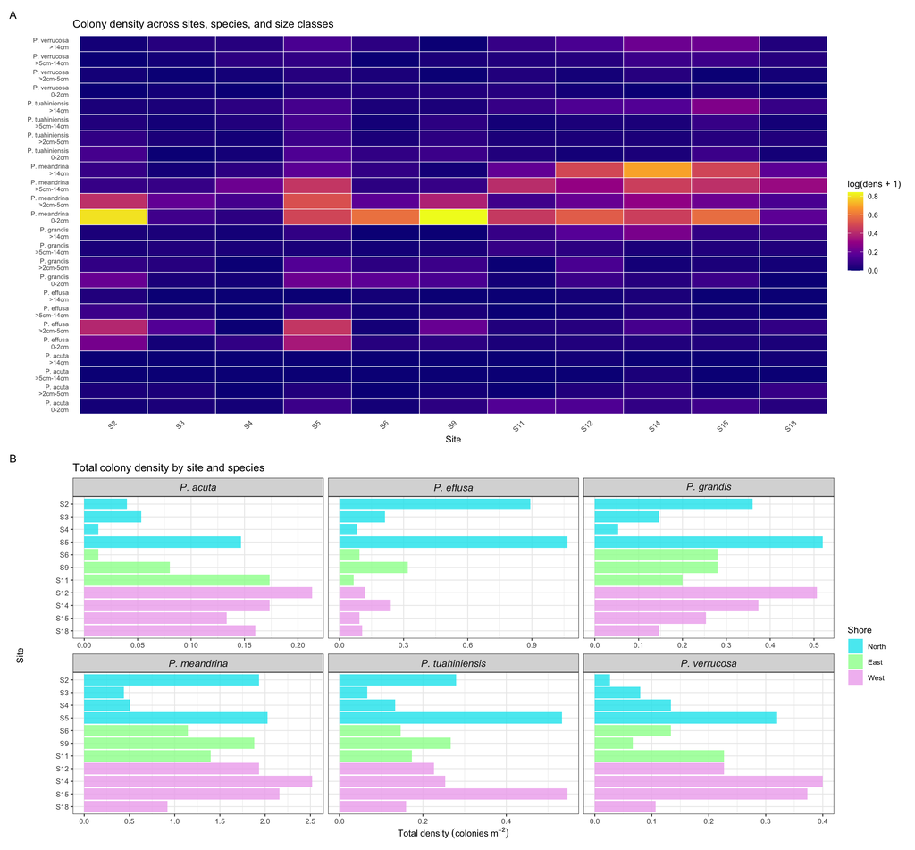

**Supplemental Figure 2.** Colony density overview. **A:** Log-transformed colony density (log[density + 1], colonies m⁻²) across all site × species × size-class combinations; zeros are included. **B:** Total colony density (summed across size classes) per site for each species.

```r
p_dens_heat / p_total_dens +
  plot_layout(heights = c(1.2, 1)) +
  plot_annotation(tag_levels = "A",
                  theme = theme(plot.tag = element_text(face = "bold", size = 12)))
```

## Proportional size-class composition

[figure not shown]

**Figure 1.** *Pocillopora* species composition and size-frequency distributions across shores in Mo’orea, French Polynesia (n = 11 sites). **A:** Site map of coral collections and benthic substrate characterization **B:**Relative abundance of each *Pocillopora* species per site, calculated from summed colony density across size classes. **C:** Mean colony density (±1 SE) per size class, species, and shore. **D:** Proportional size-class composition at each site, organized by shore. Deviations from a juvenile-dominated structure indicate sites with reduced recent recruitment or elevated small-colony mortality.

```r
(map_plot | p_rel_abund) / p_sizefreq / p_sizeprop +
  plot_layout(heights = c(0.7, 1, 1.3)) +
  plot_annotation(tag_levels = "A",
                  theme = theme(plot.tag = element_text(face = "bold", size = 12)))
```

```r
fig1 <- (map_plot | p_rel_abund) / p_sizefreq / p_sizeprop +
  plot_layout(heights = c(0.7, 1, 1.3)) +
  plot_annotation(tag_levels = "A",
                  theme = theme(plot.tag = element_text(face = "bold", size = 12)))

ggsave(here::here("Output", "Figure1.pdf"), fig1, width = 14, height = 16, units = "in")
ggsave(here::here("Output", "Figure1.jpg"), fig1, width = 14, height = 16, units = "in", dpi = 300)
```

## Interpretation

P. meandrina drives the density signal, with the highest absolute densities across all shores and size classes. Most species show a decline in density from small to large size classes, consistent with a roughly juvenile-skewed structure. P. effusa stands out on the North shore with noticeably higher densities across all size classes relative to East and West.

The West shore is the most striking — roughly a third of colonies exceed 14 cm, the inverse of the East shore. This could reflect reduced recent recruitment, greater longevity of established colonies, or differential mortality of juveniles on the West shore. The East shore’s juvenile-heavy structure is consistent with either high recent recruitment or a post-disturbance recovery trajectory.

# Multivariate community analysis

All analyses in this section use Bray–Curtis dissimilarities computed from the species × size-class density matrix. Permutation-based methods are used throughout because they make no distributional assumptions and are appropriate for the small sample size (n = 11 sites).

## NMDS ordination

nmds-run

Computes a Bray–Curtis dissimilarity matrix from comm_mat. Fits a 2D NMDS (metaMDS, k = 2, trymax = 500, seed 3947).

Prints stress and a quick guide (< 0.10 good, < 0.20 acceptable). nmds-plot (include: false)

```r
dist_bray <- vegdist(comm_mat, method = "bray")

set.seed(3947)
nmds_result <- metaMDS(
  comm_mat,
  distance = "bray",
  k        = 2,
  trymax   = 500,
  trace    = FALSE
)

cat("NMDS stress:", round(nmds_result$stress, 4), "\n")
```

```
NMDS stress: 0.059
```

```r
cat("Interpretation: < 0.10 = good, < 0.20 = acceptable, > 0.20 = interpret cautiously\n")
```

```
Interpretation: < 0.10 = good, < 0.20 = acceptable, > 0.20 = interpret cautiously
```

```r
# Fit environmental vectors in the same cached cell to avoid stale-cache issues
set.seed(3947)
ef <- envfit(nmds_result, env_mat, permutations = 999)
print(ef)
```

```
***VECTORS

                  NMDS1    NMDS2     r2 Pr(>r)
max_temp_br    -0.15864 -0.98734 0.3094  0.213
daily_range_br -0.42121 -0.90697 0.5363  0.027 *
Hard_Coral     -0.02645 -0.99965 0.4533  0.090 .
CTB_algae       0.71296  0.70120 0.5240  0.041 *
wave_P_max      0.00369 -0.99999 0.3956  0.143
---
Signif. codes:  0 '***' 0.001 '**' 0.01 '*' 0.05 '.' 0.1 ' ' 1
Permutation: free
Number of permutations: 999
```

## PERMANOVA

Because simultaneously fitting all predictors is not feasible at n = 11 (it would exhaust degrees of freedom), individual PERMANOVA tests were run for each predictor. These are marginal (unconditional) tests and do not control for covariation among predictors. Results are FDR-adjusted for multiple comparisons.

```r
set.seed(3947)
perm_results <- map_dfr(
  c("shore", env_vars),
  function(v) {
    form   <- as.formula(paste("dist_bray ~", v))
    result <- adonis2(form, data = env_perm, permutations = 999)
    tibble(
      Predictor = v,
      Df        = result$Df[1],
      R2        = result$R2[1],
      F_stat    = result$F[1],
      p_value   = result$`Pr(>F)`[1]
    )
  }
)

perm_results |>
  mutate(
    Predictor = c("Shore", env_labels),
    p_adj     = p.adjust(p_value, method = "BH"),
    sig       = case_when(
      p_adj < 0.001 ~ "***",
      p_adj < 0.01  ~ "**",
      p_adj < 0.05  ~ "*",
      p_adj < 0.10  ~ ".",
      TRUE          ~ ""
    )
  ) |>
  kable(
    digits    = c(0, 0, 3, 3, 4, 4, 0),
    col.names = c("Predictor", "df", "R²", "F", "p", "p (FDR)", ""),
    caption   = "Individual PERMANOVA results (adonis2, Bray–Curtis, 999 permutations). Each predictor tested separately. R² = proportion of community dissimilarity explained."
  ) |>
  kable_styling(bootstrap_options = c("striped", "hover"))
```

Individual PERMANOVA results (adonis2, Bray–Curtis, 999 permutations). Each predictor tested separately. R² = proportion of community dissimilarity explained.

| Predictor | df | R² | F | p | p (FDR) |  |
| --- | --- | --- | --- | --- | --- | --- |
| Shore | 2 | 0.281 | 1.563 | 0.179 | 0.1790 |  |
| Max temp (°C) | 1 | 0.169 | 1.828 | 0.137 | 0.1644 |  |
| Daily temp range (°C) | 1 | 0.214 | 2.446 | 0.028 | 0.1120 |  |
| Hard coral | 1 | 0.203 | 2.288 | 0.056 | 0.1120 |  |
| CTB + Macro | 1 | 0.215 | 2.469 | 0.038 | 0.1120 |  |
| Max wave power | 1 | 0.194 | 2.162 | 0.081 | 0.1215 |  |

**Interpretation.** No predictor survived FDR correction (all p<sub>adj</sub> ≥ 0.112), which is expected at n = 11; with only 11 sites, permutation tests have few unique arrangements and little power to detect moderate effects. R² (proportion of Bray–Curtis dissimilarity explained) is therefore the more informative quantity. Shore identity has the largest marginal R² (R² = 0.281, p = 0.179), indicating that geographic position accounts for more community variation than any single environmental predictor — though it too is underpowered. Among individual predictors, CTB + Macro (R² = 0.215, p = 0.038) and daily temperature range (R² = 0.214, p = 0.028) are the only two with nominal p < 0.05 and are nearly identical in explanatory power, together suggesting that the CTB–macroalgae benthic cover gradient (reflecting both recruitment substrate availability and macroalgal competition pressure) and thermal variability are the primary environmental correlates of community composition. Hard coral cover is marginal (R² = 0.203, p = 0.056), followed by maximum wave power (R² = 0.194, p = 0.081) and maximum temperature (R² = 0.169, p = 0.137). These results are consistent with the envfit ordination, where CTB + Macro and daily temperature range were the two significant vector fits.

# Mantel and partial Mantel tests

Mantel tests correlate community dissimilarity (Bray–Curtis) with distances in single environmental predictors — a permutation-based approach with no distributional assumptions, well-suited to small n. The **partial Mantel test** extends this to control for geographic structure (shore): it regresses out the effect of a binary shore-distance matrix (same shore = 0, different shore = 1) before testing each predictor. This is critical given the North/West/East gradient in Mo’orea, which may confound individual predictor effects.

What is the relationship between community dissimilarity and each environmental predictors without controlling for shore (unconditional) and with controlling for shore (partial)? Ho: There is no relationship between community dissimilarity and each environmental predictors

```r
# Geographic distance proxy: 0 = same shore, 1 = different shore
shore_vec <- env_clean |> arrange(site.name) |> pull(shore)
geo_dist  <- as.dist(
  outer(as.character(shore_vec), as.character(shore_vec),
        FUN = function(a, b) as.numeric(a != b))
)
```

```r
set.seed(3947)
mantel_results <- map_dfr(env_vars, function(v) {
  # Euclidean distance on the single standardized predictor
  env_d <- dist(scale(env_mat[[v]]))

  m  <- mantel(dist_bray, env_d, method = "spearman", permutations = 9999)
  pm <- mantel.partial(dist_bray, env_d, geo_dist,
                       method = "spearman", permutations = 9999)

  tibble(
    Predictor  = env_label_map[v],
    mantel_r   = round(m$statistic,  3),
    mantel_p   = round(m$signif,     4),
    partial_r  = round(pm$statistic, 3),
    partial_p  = round(pm$signif,    4)
  )
})

mantel_results |>
  mutate(
    mantel_sig  = case_when(mantel_p  < 0.05 ~ "*", mantel_p  < 0.10 ~ ".", TRUE ~ ""),
    partial_sig = case_when(partial_p < 0.05 ~ "*", partial_p < 0.10 ~ ".", TRUE ~ "")
  ) |>
  kable(
    col.names = c("Predictor",
                  "Mantel r", "p", "",
                  "Partial r", "p (|shore)", ""),
    caption = "Mantel (unconditional) and partial Mantel (controlling for shore) tests between community Bray–Curtis dissimilarity and individual environmental predictors. Spearman correlation statistic; 9,999 permutations."
  ) |>
  kable_styling(bootstrap_options = c("striped", "hover"))
```

Mantel (unconditional) and partial Mantel (controlling for shore) tests between community Bray–Curtis dissimilarity and individual environmental predictors. Spearman correlation statistic; 9,999 permutations.

| Predictor | Mantel r | p |  | Partial r | p (\|shore) |  |
| --- | --- | --- | --- | --- | --- | --- |
| Max temp (°C) | 0.200 | 0.0917 | 0.175 | 0.1237 | . |  |
| Daily temp range (°C) | 0.156 | 0.1856 | 0.142 | 0.2080 |  |  |
| Hard coral | 0.280 | 0.0336 | 0.257 | 0.0484 | * | * |
| CTB + Macro | 0.427 | 0.0170 | 0.433 | 0.0160 | * | * |
| Max wave power | 0.153 | 0.1115 | 0.094 | 0.2726 |  |  |

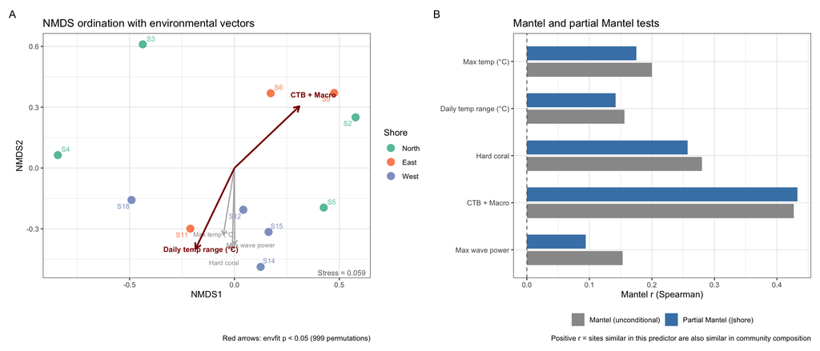

**Figure 2.** Multivariate analysis of *Pocillopora* community composition (species × size-class density matrix, Bray–Curtis dissimilarity). **A:** NMDS ordination (stress = 0.059). Dark red arrows = significant envfit vectors (daily temperature range: r² = 0.536, p = 0.027; CTB + Macro: r² = 0.524, p = 0.041; 999 permutations); grey arrows = non-significant. The opposing arrow directions indicate that sites with high thermal variability tend to have lower CTB and macroalgae cover. **B:** Simple (grey) and partial Mantel r statistics controlling for shore (blue). CTB + Macro is the strongest predictor of community dissimilarity (simple r = 0.43, p = 0.017) and retains this signal after controlling for shore geography (partial r = 0.43, p = 0.016), indicating the CTB–macroalgae cover gradient is independent of site location.

```r
fig2 <- p_nmds_ord + p_mantel +
  plot_layout(widths = c(1.1, 1)) +
  plot_annotation(tag_levels = "A",
                  theme = theme(plot.tag = element_text(face = "bold", size = 12)))

ggsave(here::here("Output", "Figure2.pdf"), fig2, width = 14, height = 6, units = "in")
ggsave(here::here("Output", "Figure2.jpg"), fig2, width = 14, height = 6, units = "in", dpi = 300)
fig2
```

**Interpretation.** CTB + Macro produces the strongest and most consistent signal: simple Mantel r = 0.427 (p = 0.017), and the partial Mantel — controlling for geographic shore structure — is nearly identical (r = 0.433, p = 0.016). The fact that the partial correlation is no weaker than the simple correlation suggests the CTB–macroalgae cover gradient is not simply a proxy for shore identity; it retains an independent association with community dissimilarity after geographic position is accounted for. Hard coral cover is also significant in both tests (r = 0.280, p = 0.034; partial r = 0.257, p = 0.048), indicating that sites with similar coral cover tend to host more similar *Pocillopora* communities, independently of shore. The remaining predictors — daily temperature range, maximum temperature, and wave power — are not significant in either Mantel test (all p ≥ 0.09). This is a notable contrast with the PERMANOVA and envfit results, where daily temperature range was the most consistently significant predictor. The discrepancy likely reflects a difference in what each method measures: PERMANOVA and envfit capture the overall multivariate association between a predictor and community composition, whereas the Mantel test specifically asks whether sites that are more dissimilar in a single predictor also tend to be more dissimilar in community composition — a relationship that may be weaker or non-monotonic for temperature. Taken together, CTB + Macro — capturing both the availability of hard substrate for larval settlement (CTB) and the pressure of macroalgal competition on established colonies — emerges as the most robust predictor of community dissimilarity across all three multivariate approaches.

# Species–environment correlations

## Spearman correlation heatmap

Spearman rank correlations between colony density and each environmental predictor were computed for every species × size-class combination (n = 11 sites per correlation). All 120 p-values (5 predictors × 6 species × 4 size classes) were adjusted jointly using the Benjamini–Hochberg FDR procedure. Given n = 11, these tests have low statistical power and results should be treated as exploratory indicators of effect direction and magnitude rather than confirmatory evidence.

```r
sp_size_combos <- data_full |>
  distinct(Species, SizeClass) |>
  arrange(Species, SizeClass)

cor_results <- map_dfr(seq_len(nrow(sp_size_combos)), function(i) {
  sp <- as.character(sp_size_combos$Species[i])
  sz <- as.character(sp_size_combos$SizeClass[i])

  sub <- data_full |>
    filter(as.character(Species)   == sp,
           as.character(SizeClass) == sz)

  map_dfr(seq_along(env_vars), function(j) {
    test <- cor.test(sub$Density_m2, sub[[env_vars[j]]],
                     method = "spearman", exact = FALSE)
    tibble(
      Species   = sp,
      SizeClass = sz,
      EnvVar    = env_labels[j],
      rho       = as.numeric(test$estimate),
      p_value   = test$p.value
    )
  })
}) |>
  mutate(
    p_adj     = p.adjust(p_value, method = "BH"),
    sig_label = case_when(
      p_adj < 0.05 ~ "*",
      p_adj < 0.10 ~ ".",
      TRUE         ~ ""
    ),
    SizeClass = factor(SizeClass, levels = size_levels),
    Species   = factor(Species,   levels = species_levels),
    EnvVar    = factor(EnvVar,    levels = env_labels)
  )
```

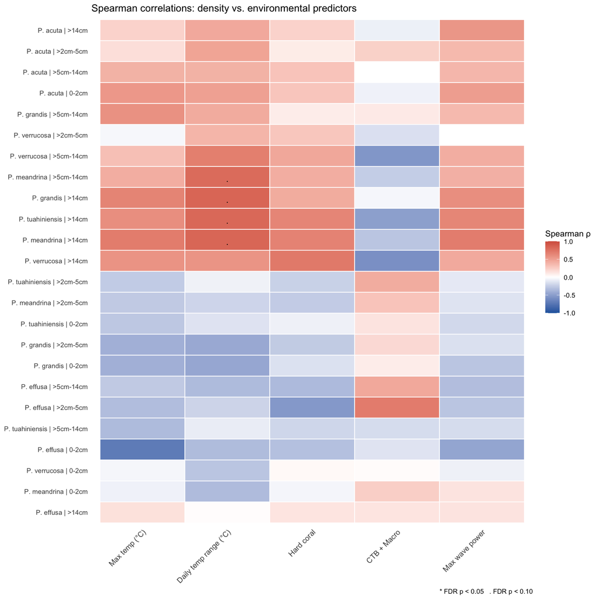

```r
# Build wide rho matrix for clustering rows (sp_size) by correlation profile
rho_wide <- cor_results |>
  mutate(sp_size = paste(as.character(Species), as.character(SizeClass), sep = " | ")) |>
  select(sp_size, EnvVar, rho) |>
  pivot_wider(names_from = EnvVar, values_from = rho) |>
  column_to_rownames("sp_size")

row_order <- hclust(dist(rho_wide), method = "ward.D2")$order
clustered_levels <- rownames(rho_wide)[row_order]

cor_results |>
  mutate(
    sp_size = factor(
      paste(as.character(Species), as.character(SizeClass), sep = " | "),
      levels = clustered_levels
    )
  ) |>
  ggplot(aes(x = EnvVar, y = sp_size, fill = rho)) +
  geom_tile(color = "white", linewidth = 0.4) +
  geom_text(aes(label = sig_label), size = 3.8, vjust = 0.75) +
  scale_fill_gradient2(
    low      = "#2166AC",
    mid      = "white",
    high     = "#D6604D",
    midpoint = 0,
    limits   = c(-1, 1),
    name     = "Spearman ρ"
  ) +
  labs(
    x       = NULL,
    y       = NULL,
    title   = "Spearman correlations: density vs. environmental predictors",
    caption = "* FDR p < 0.05   . FDR p < 0.10"
  ) +
  theme_minimal(base_size = 10) +
  theme(
    axis.text.x = element_text(angle = 45, hjust = 1, size = 9),
    axis.text.y = element_text(size  = 8),
    panel.grid  = element_blank()
  )
```

**Interpretation.** Hierarchical clustering of the ρ profiles reveals two broad groupings. The upper cluster captures species–size combinations with predominantly positive associations across thermal and wave predictors: large adults (>14 cm) of *P. grandis* (ρ = 0.84), *P. meandrina* (ρ = 0.83), and *P. tuahiniensis* (ρ = 0.82), as well as *P. meandrina* sub-adults (>5–14 cm, ρ = 0.80) show the strongest positive associations with daily temperature range. These four are the only tests approaching FDR-corrected significance (p<sub>adj</sub> ≈ 0.087–0.097, labeled “.”), and the effect is concentrated in larger size classes — not recruits or juveniles — suggesting that adult persistence, not recruitment, is correlated with the thermal variability gradient. The lower cluster groups species–size combinations with near-zero or negative ρ values, most notably *P. effusa* across all size classes. *P. effusa* juveniles (0–2 cm) show the strongest negative association with maximum temperature in the dataset (ρ = −0.71), consistent with thermal sensitivity of early life stages for this species.

The CTB + Macro composite shows a size-class-dependent pattern that is ecologically interpretable given the distinct roles of its two components: CTB provides hard substrate that facilitates larval settlement and recruitment, while macroalgae can compete with, damage, or smother larger established colonies and block larval settlement. Consistent with a CTB-driven recruitment facilitation effect, small and sub-adult size classes of *P. effusa* (>2–5 cm: ρ = 0.70; >5–14 cm: ρ = 0.45) and *P. tuahiniensis* (>2–5 cm: ρ = 0.43) show positive associations with CTB + Macro. In contrast, large adults (>14 cm) of *P. verrucosa* (ρ = −0.58), *P. tuahiniensis* (ρ = −0.49), and *P. meandrina* (ρ = −0.29) show negative associations, consistent with a macroalgae competition or smothering effect on established colonies. This divergence — positive for small size classes, negative for large adults — is coherent with the hypothesis that the CTB component of the composite benefits recruits while the macroalgae component suppresses adults. However, because the two components cannot be separated within this composite, these interpretations are inferential and should be tested with the components modelled independently where sample size allows. All FDR-adjusted p-values are large (all p<sub>adj</sub> ≥ 0.087) due to the number of simultaneous tests (5 predictors × 6 species × 4 size classes = 120); effect sizes (ρ) are the appropriate basis for interpretation.

# Multivariate GLMs: environmental drivers of species composition

Collapsing across size classes to ask whether environmental variables predict *which species are present and how abundant they are* — independent of size structure — uses multivariate generalized linear models (`manyglm`, `mvabund` package). This fits a negative binomial GLM to each species simultaneously and tests multivariate hypotheses via bootstrap resampling, accounting for the mean-variance relationship that distance-based methods like PERMANOVA ignore. Univariate models (one predictor at a time) are used for the same reasons as throughout this pipeline.

Ho: Species presence and abundance is independent of size structure

```r
# Species-only response matrix (density summed across size classes)
species_mat <- size_complete |>
  group_by(site.name, Species) |>
  summarize(density = sum(Density_m2), .groups = "drop") |>
  pivot_wider(names_from = Species, values_from = density, values_fill = 0) |>
  arrange(site.name) |>
  column_to_rownames("site.name") |>
  as.matrix()

spp <- mvabund(species_mat)
cat("Response matrix:", nrow(species_mat), "sites ×", ncol(species_mat), "species\n")
```

```
Response matrix: 11 sites × 6 species
```

```r
# Standardized predictor data frame (z-scored, same site order as species_mat)
env_perm_z <- env_clean |>
  arrange(site.name) |>
  mutate(shore = as.character(shore)) |>
  column_to_rownames("site.name") |>
  mutate(across(all_of(env_vars), ~scale(.)[, 1]))
```

```r
# Species name lookup (manyglm replaces ". " with ".." in column names)
spp_name_map <- c(
  "P..acuta"        = "P. acuta",
  "P..effusa"       = "P. effusa",
  "P..grandis"      = "P. grandis",
  "P..meandrina"    = "P. meandrina",
  "P..tuahiniensis" = "P. tuahiniensis",
  "P..verrucosa"    = "P. verrucosa"
)

set.seed(3947)
mva_results <- map_dfr(env_vars, function(v) {
  form <- as.formula(paste("spp ~", v))
  fit  <- manyglm(form, data = env_perm_z, family = "negative.binomial")
  av   <- anova(fit, p.uni = "adjusted", nBoot = 999, show.time = "none")
  raw_names <- names(av$uni.p[2, ])
  tibble(
    Predictor = env_label_map[v],
    mv_p      = av$table[2, "Pr(>Dev)"],
    Species   = factor(spp_name_map[raw_names], levels = species_levels),
    uni_p_adj = av$uni.p[2, ],
    coef      = coef(fit)[2, ]
  )
}) |>
  mutate(Predictor = factor(Predictor, levels = env_labels))

# Also run PERMANOVA on species-only matrix for R² comparison
dist_spp_only <- vegdist(species_mat[order(rownames(species_mat)), ], method = "bray")

set.seed(3947)
perm_spp <- map_dfr(env_vars, function(v) {
  form   <- as.formula(paste("dist_spp_only ~", v))
  result <- adonis2(form, data = env_perm, permutations = 999)
  tibble(Predictor = env_label_map[v],
         R2_spp    = result$R2[1],
         p_spp     = result$`Pr(>F)`[1])
}) |>
  left_join(
    perm_results |>
      filter(Predictor != "shore") |>
      mutate(Predictor = env_labels) |>
      select(Predictor, R2_full = R2, p_full = p_value),
    by = "Predictor"
  ) |>
  mutate(Predictor = factor(Predictor, levels = env_labels))

cat("Multivariate manyglm results:\n")
```

```
Multivariate manyglm results:
```

```r
mva_results |>
  distinct(Predictor, mv_p) |>
  arrange(mv_p) |>
  kable(digits = 3,
        col.names = c("Predictor", "Multivariate p (999 boots)"),
        caption = "manyglm: no predictor significantly affects Pocillopora species composition.") |>
  kable_styling(bootstrap_options = c("striped", "hover"), full_width = FALSE)
```

manyglm: no predictor significantly affects Pocillopora species composition.

| Predictor | Multivariate p (999 boots) |
| --- | --- |
| Max temp (°C) | 0.228 |
| Max wave power | 0.259 |
| Hard coral | 0.326 |
| CTB + Macro | 0.368 |
| Daily temp range (°C) | 0.520 |